# Prediction of Event Status

1. Overview
2. Libraries
3. Data Collection
4. Quick Data Exploration (Before Cleaning)
5. Data Cleaning
6. Data Visualization/ Exploration
7. Data Preprocessing
8. Baseline Model
9. Other ML Models
10. Conclusion

## 1. Overview

#### Problem Statement

In this project, I will be predicting whether events will be cancelled or not based on event and weather conditions data. In addition, I will also explore the relationship between events and the weather, and apply machine learning models to validate my findings.

#### Step-By-Step Process

1. Collect data from multiple sources
2. Explore data
3. Apply machine learning models for Benchmarking Purposes
4. Clean/ Preprocess data
5. Apply machine learning models
6. Conclusion

## 2. Libraries

```python
# Numerical Python
import numpy as np

# Data Manipulation
import pandas as pd

# Date/Time
import datetime

# Getting API Data
import os
import json
import requests
import collections

# Charts and Graphs
import plotly as py
import plotly.graph_objs as go
from plotly.offline import init_notebook_mode, iplot
from plotly.subplots import make_subplots
py.offline.init_notebook_mode(connected=True)
import matplotlib.pyplot as plt

# Scikit-Learn/ Ibmlearn
from sklearn import svm
from sklearn import tree
from sklearn.pipeline import Pipeline
from imblearn.over_sampling import SMOTE
from sklearn.ensemble import RandomForestClassifier
from sklearn.tree import DecisionTreeClassifier
from sklearn.linear_model import LogisticRegression
from sklearn.preprocessing import LabelEncoder, OneHotEncoder, StandardScaler
from sklearn.model_selection import train_test_split
from sklearn.metrics import roc_auc_score, plot_confusion_matrix
from sklearn.model_selection import GridSearchCV

# Calculating Distance
import haversine as hs
from haversine import Unit

# Text Data
import nltk
from nltk.tokenize import word_tokenize
from nltk.corpus import stopwords
```

## 3. Data Collection

#### a. CSV Files (Sample_events, Sample_Venues)

###### Reading Files

```python
sample_events_data = pd.read_csv('C:/Users/mayur/OneDrive/Desktop/Eve/sample_events.csv')
```

```python
sample_venues_data = pd.read_csv('C:/Users/mayur/OneDrive/Desktop/Eve/sample_venues.csv')
```

###### Quick Overview - Sample_Events Data

```python
# Checking head
sample_events_data.head(3)
```

|  | category | event_name | cancellation_status | cancellation_reason | rescheduled_date | venue_name | event_rating | event_type | date | start_date | end_date | min_age | description | goingto_count | entry_price |
| --- | --- | --- | --- | --- | --- | --- | --- | --- | --- | --- | --- | --- | --- | --- | --- |
| 0 | LIVE | Hallowed Drove: The Futureheads (Barry Hyde Ac... | 0 | NaN | NaN | The Warehouse Penrith | 4 | Nightclub | 2017-10-28 | 2017-10-28T20:00:00+00:00 | 2017-10-29T00:00:00+00:00 | 18 | Join us to party into the night - 4 hours of l... | 77 | 5 |
| 1 | THEATRE | Rita, Sue and Bob Too | 0 | NaN | NaN | Cast | 0 | Theatre | 2017-11-07 | 2017-11-07T19:30:00+00:00 | 2017-11-10T19:30:00+00:00 | 15 | A vivid portrait of girls caught between bruta... | 0 | £18.50 (£16.50 concs) |
| 2 | LIVE | Absolute Bowie | 0 | NaN | NaN | Old Fire Station | 4 | live | 2017-10-27 | 2017-10-27T20:00:00+00:00 | 2017-10-27T23:30:00+00:00 | 18 | Absolute Bowie: Celebrating the life of David ... | 44 | 15.00 |

```python
# Checking tail - To ensure all the data has been loaded
sample_events_data.tail(3)
```

|  | category | event_name | cancellation_status | cancellation_reason | rescheduled_date | venue_name | event_rating | event_type | date | start_date | end_date | min_age | description | goingto_count | entry_price |
| --- | --- | --- | --- | --- | --- | --- | --- | --- | --- | --- | --- | --- | --- | --- | --- |
| 297 | EXHIB | The Power of One | 0 | NaN | NaN | City Hall | 0 | Other | NaN | 2017-10-31T08:30:00+00:00 | 2017-11-14T17:30:00+00:00 | 0 | The Power of One, a photography exhibition shi... | 0 | £0 |
| 298 | LIVE | Jazz in the Afternoon | 0 | NaN | NaN | The Clarendon Hotel | 0 | Hotel | NaN | 2017-10-29T16:00:00+00:00 | 2017-10-29T19:00:00+00:00 | 18 | An afternoon of music and improvisation in the... | 0 | FREE |
| 299 | CLUB | Easy Skankin | 0 | NaN | NaN | The New Adelphi Hull | 4 | live | NaN | 2017-11-04T20:00:00+00:00 | 2017-11-05T00:00:00+00:00 | 18 | DJs J-Large and The Reverend are back from the... | 0 | £3 otd |

```python
# Checking the shape
sample_events_data.shape
```

```
(300, 15)
```

```python
# Checking data type in each column/ memory usage
sample_events_data.info()
```

```
<class 'pandas.core.frame.DataFrame'>
RangeIndex: 300 entries, 0 to 299
Data columns (total 15 columns):
category               300 non-null object
event_name             300 non-null object
cancellation_status    300 non-null int64
cancellation_reason    10 non-null object
rescheduled_date       3 non-null object
venue_name             300 non-null object
event_rating           300 non-null int64
event_type             300 non-null object
date                   108 non-null object
start_date             300 non-null object
end_date               300 non-null object
min_age                300 non-null int64
description            300 non-null object
goingto_count          300 non-null int64
entry_price            300 non-null object
dtypes: int64(4), object(11)
memory usage: 35.3+ KB
```

```python
# Looking at null values
sample_events_data.isnull().sum().sort_values(ascending = False)
```

```
rescheduled_date       297
cancellation_reason    290
date                   192
entry_price              0
goingto_count            0
description              0
min_age                  0
end_date                 0
start_date               0
event_type               0
event_rating             0
venue_name               0
cancellation_status      0
event_name               0
category                 0
dtype: int64
```

```python
# Finding duplicate Rows
sample_events_data_dup = sample_events_data[sample_events_data.duplicated()]
sample_events_data_dup.head(3)
```

|  | category | event_name | cancellation_status | cancellation_reason | rescheduled_date | venue_name | event_rating | event_type | date | start_date | end_date | min_age | description | goingto_count | entry_price |
| --- | --- | --- | --- | --- | --- | --- | --- | --- | --- | --- | --- | --- | --- | --- | --- |
| 47 | FEST | Resident Evil Live Playthrough | 0 | NaN | NaN | The Banshee Labyrinth | 4 | live | 2017-10-27 | 2017-10-27T14:00:00+00:00 | 2017-10-31T16:30:00+00:00 | 18 | Live playthrough of the survival horror gaming... | 0 | Free |
| 160 | THEATRE | Son of a Preacher Man | 0 | NaN | NaN | Assembly Hall Theatre Tunbridge Wells | 0 | live | NaN | 2017-10-31T19:30:00+00:00 | 2017-11-04T22:00:00+00:00 | 0 | Three broken hearts, one Soho hang-out, and th... | 0 | Front Stalls & Circle From: £15. |
| 206 | FOOD | Book your Christmas Party | 0 | NaN | NaN | Shaka Zulu | 3 | Nightclub | NaN | 2017-11-01T18:00:00+00:00 | 2017-11-15T20:00:00+00:00 | 0 | The nights are drawing in, there's a chill in ... | 0 | Packages start from: GBP 45 |

```python
# Removing Duplicate Rows
sample_events_data.drop_duplicates(subset=None, keep='first', inplace=True)
sample_events_data.shape
```

```
(294, 15)
```

```python
# Converting to datetime
sample_events_data['event_start_datetime'] = pd.to_datetime(sample_events_data['start_date'])
sample_events_data['event_start_datetime'] = sample_events_data['event_start_datetime'].apply(lambda x: x.strftime("%Y/%m/%d %H:%M:%S"))
```

##### Quick Overview - Sample_Venues Data

```python
# Checking head
sample_venues_data.head()
```

|  | venue_name | address | city_name | country_name | longitude | latitude | postcode | capacity | venue_size | venue_type_new | venue_status |
| --- | --- | --- | --- | --- | --- | --- | --- | --- | --- | --- | --- |
| 0 | Camberley Theatre | Knoll Road | Camberley | GB | -0.743443 | 51.338473 | GU15 3SY | NaN | NaN | 2_indoor | perminant |
| 1 | The Leadmill | 6 Leadmill Road | Sheffield | GB | -1.465040 | 53.376191 | S1 4SE | NaN | NaN | 3_indoor_outdoor | perminant |
| 2 | Bierkeller Manchester | Unit 12, The Printworks, 27 Withy Grove | Manchester | GB | -2.240614 | 53.485156 | M4 2BS | NaN | NaN | 2_indoor | perminant |
| 3 | St Marks Church St Marks Road Leeds LS2 9AF | St Marks Road | Leeds | GB | -1.552703 | 53.811566 | LS2 9AF | NaN | NaN | 2_indoor | perminant |
| 4 | Lincoln Drill Hall | Freeschool Lane | Lincoln | GB | -0.537330 | 53.229871 | LN2 1EY | NaN | NaN | 2_indoor | perminant |

```python
# Checking tail - To ensure all the data has been loaded
sample_venues_data.tail()
```

|  | venue_name | address | city_name | country_name | longitude | latitude | postcode | capacity | venue_size | venue_type_new | venue_status |
| --- | --- | --- | --- | --- | --- | --- | --- | --- | --- | --- | --- |
| 331 | Rumours Nightclub Wynford Hotel | Wynford Hotel, Clare Street, Cardiff. CF11 6BD | Cardiff | GB | -3.188474 | 51.477694 | CF11 6bd | NaN | NaN | 2_indoor | perminant |
| 332 | Bosworth Battlefield Heritage Centre | Ambion Lane, Sutton Cheney | Nuneaton | GB | -1.405779 | 52.597282 | CV13 0AD | NaN | NaN | 1_outdoor | temporary |
| 333 | The Basement Club | 13-15 Marsh Street South, Hanley, Stoke-on-Tre... | Stoke-on-Trent | GB | -2.178505 | 53.024109 | ST1 1JA | NaN | NaN | 2_indoor | perminant |
| 334 | Madison London | Terrace, One New Change, St Paul&#39;s, | London | GB | -0.095218 | 51.513538 | EC4M 9AF | NaN | NaN | 2_indoor | perminant |
| 335 | Lola Lo | Arches 9 - 10 Deansgate Locks, Whitworth Stree... | Manchester | GB | -2.249912 | 53.474641 | M1 5LH | NaN | NaN | 2_indoor | perminant |

```python
# Checking the shape
sample_venues_data.shape
```

```
(336, 11)
```

```python
# Checking data type in each column
sample_venues_data.info()
```

```
<class 'pandas.core.frame.DataFrame'>
RangeIndex: 336 entries, 0 to 335
Data columns (total 11 columns):
venue_name        336 non-null object
address           336 non-null object
city_name         336 non-null object
country_name      336 non-null object
longitude         336 non-null float64
latitude          336 non-null float64
postcode          336 non-null object
capacity          5 non-null object
venue_size        5 non-null object
venue_type_new    336 non-null object
venue_status      336 non-null object
dtypes: float64(2), object(9)
memory usage: 29.0+ KB
```

```python
# Looking at null values
sample_events_data.isnull().sum().sort_values(ascending = False)
```

```
rescheduled_date        291
cancellation_reason     284
date                    187
event_start_datetime      0
entry_price               0
goingto_count             0
description               0
min_age                   0
end_date                  0
start_date                0
event_type                0
event_rating              0
venue_name                0
cancellation_status       0
event_name                0
category                  0
dtype: int64
```

```python
# Finding duplicate Rows
sample_venues_data_dup = sample_venues_data[sample_venues_data.duplicated()]
sample_venues_data_dup.shape
```

```
(71, 11)
```

```python
# Removing Duplicate Rows
sample_venues_data.drop_duplicates(subset=None, keep='first', inplace=True)
sample_venues_data.shape
```

```
(265, 11)
```

#### b. Merging data into Single Dataframe

```python
# Merging CSV files
data = pd.merge(sample_events_data, sample_venues_data, how='left', on=['venue_name'])
```

```python
data.shape # There are 4 extra rows here compared to sample_events table
```

```
(298, 26)
```

```python
# Removing the 4 extra rows based on description/ event_type/ online
data = data.drop(data.index[[100,152,235,249]])
```

```python
data.shape # This Dataframe now matches the events dataframe in terms of rows
```

```
(294, 26)
```

```python
data.head(3)
```

|  | category | event_name | cancellation_status | cancellation_reason | rescheduled_date | venue_name | event_rating | event_type | date | start_date | ... | address | city_name | country_name | longitude | latitude | postcode | capacity | venue_size | venue_type_new | venue_status |
| --- | --- | --- | --- | --- | --- | --- | --- | --- | --- | --- | --- | --- | --- | --- | --- | --- | --- | --- | --- | --- | --- |
| 0 | LIVE | Hallowed Drove: The Futureheads (Barry Hyde Ac... | 0 | NaN | NaN | The Warehouse Penrith | 4 | Nightclub | 2017-10-28 | 2017-10-28T20:00:00+00:00 | ... | 43 Burrowgate | Penrith | GB | -2.751901 | 54.664948 | CA11 7TA | NaN | NaN | 2_indoor | perminant |
| 1 | THEATRE | Rita, Sue and Bob Too | 0 | NaN | NaN | Cast | 0 | Theatre | 2017-11-07 | 2017-11-07T19:30:00+00:00 | ... | Waterdale | Doncaster | GB | -1.131768 | 53.519857 | DN1 3BU | NaN | NaN | 2_indoor | perminant |
| 2 | LIVE | Absolute Bowie | 0 | NaN | NaN | Old Fire Station | 4 | live | 2017-10-27 | 2017-10-27T20:00:00+00:00 | ... | Warwick St | Carlisle | GB | -2.936500 | 54.897063 | CA3 8QP | NaN | NaN | 2_indoor | perminant |

3 rows × 26 columns

#### c. Dark Sky API

```python
# Getting unique values - Can perhaps help with cost saving, although the disadvantage would be storage
df_weather = data[['latitude','longitude','start_date']]
print(df_weather.head(3))
print('df_weather with all Information: ',df_weather.shape)

# Removing Duplicates
df_weather.drop_duplicates(subset=None, keep='first', inplace=True)
print('df_weather after dropping duplicates: ',df_weather.shape)
df_weather.reset_index(drop=True, inplace=True)
```

```
    latitude  longitude                 start_date
0  54.664948  -2.751901  2017-10-28T20:00:00+00:00
1  53.519857  -1.131768  2017-11-07T19:30:00+00:00
2  54.897063  -2.936500  2017-10-27T20:00:00+00:00
df_weather with all Information:  (294, 3)
df_weather after dropping duplicates:  (282, 3)
```

```python
# Function for Flattening Nested Dictionary
def flatten(d,sep="_"):
    obj = collections.OrderedDict()

    def recurse(t,parent_key=""):

        if isinstance(t,list):
            for i in range(len(t)):
                recurse(t[i],parent_key + sep + str(i) if parent_key else str(i))
        elif isinstance(t,dict):
            for k,v in t.items():
                recurse(v,parent_key + sep + k if parent_key else k)
        else:
            obj[parent_key] = t

    recurse(d)

    return obj
```

```python
# Setting batch size for APIs
def batch(iterable, n=10):
    l = len(iterable)
    for ndx in range(0, l, n):
        yield iterable[ndx:min(ndx + n, l)]

# Fetchin api function
def fetch_api_data(fname, api_key, dataframe, n=10):
    for x in batch(range(len(dataframe)), n):
        for i in x:
            url = 'https://api.darksky.net/forecast/%s/%s,%s,%s?units=uk2&exclude= \
                hourly,offset' %(api_key, dataframe['latitude'][i], dataframe['longitude'][i], dataframe['start_date'][i])
            try:
                response = requests.get(url, timeout=5)
                response.raise_for_status()
            except requests.exceptions.HTTPError as http_error:
                print(http_error)
            except requests.exceptions.ConnectionError as connection_error:
                print(connection_error)
            except requests.exceptions.Timeout as timeout_error:
                print(timeout_error)
            except requests.exceptions.RequestException as exception:
                print(exception)
                print(url)

            dark_sky_data = response.json()

            a = []
            # Getting json data and adding it to file
            if not os.path.isfile(fname):
                a.append(flatten(dark_sky_data))
                with open(fname, mode='w') as f:
                    f.write(json.dumps(a))
            else:
                with open(fname) as feedsjson:
                    feeds = json.load(feedsjson)

                feeds.append(flatten(dark_sky_data))
                with open(fname, mode='w') as f:
                    f.write(json.dumps(feeds))

    df = pd.read_json(fname)
    return df
```

```python
# Fetching data from dark sky api using the function above
api_key = 'ca316c68591a58161c2d0b7986a28273'
fname = 'weather_api_data.json'
weather_file = fetch_api_data(fname, api_key, df_weather, n=30)
```

```python
weather_file.head(3)
```

|  | latitude | longitude | timezone | currently_time | currently_summary | currently_icon | currently_precipIntensity | currently_precipProbability | currently_temperature | currently_apparentTemperature | ... | daily_data_0_apparentTemperatureMaxTime | flags_sources_0 | flags_sources_1 | flags_sources_2 | flags_sources_3 | flags_sources_4 | flags_nearest-station | flags_units | offset | currently_precipType |
| --- | --- | --- | --- | --- | --- | --- | --- | --- | --- | --- | --- | --- | --- | --- | --- | --- | --- | --- | --- | --- | --- |
| 0 | 54.664948 | -2.751901 | Europe/London | 2017-10-28 20:00:00 | Overcast | cloudy | 0.0000 | 0.00 | 12.94 | 12.94 | ... | 1.509213e+09 | cmc | gfs | icon | isd | madis | 10.757 | uk2 | 1 | NaN |
| 1 | 53.519857 | -1.131768 | Europe/London | 2017-11-07 19:30:00 | Partly Cloudy | partly-cloudy-night | 0.0283 | 0.12 | 6.94 | 5.37 | ... | 1.510056e+09 | cmc | gfs | icon | isd | madis | 6.001 | uk2 | 0 | rain |
| 2 | 54.897063 | -2.936500 | Europe/London | 2017-10-27 20:00:00 | Mostly Cloudy | partly-cloudy-night | 0.0000 | 0.00 | 9.21 | 5.98 | ... | 1.509116e+09 | cmc | gfs | icon | isd | madis | 2.767 | uk2 | 1 | NaN |

3 rows × 66 columns

```python
# Converting 'currently_time'
weather_file['currently_time'] = weather_file['currently_time'].apply(lambda x: x.strftime("%Y/%m/%d %H:%M:%S"))
```

```python
# Rounding longitude
weather_file[['longitude', 'latitude']] = weather_file[['longitude', 'latitude']].round(10)
data[['longitude', 'latitude']] = data[['longitude', 'latitude']].round(10)
```

#### d. Merging All Data

```python
# Merging Dark Sky API with 'data' dataframe
all_data = pd.merge(data, weather_file, how='left', left_on=['latitude', 'longitude', 'event_start_datetime'],
                    right_on=['latitude', 'longitude', 'currently_time']).reset_index(drop=True)
```

```python
all_data.head(3)
```

|  | category | event_name | cancellation_status | cancellation_reason | rescheduled_date | venue_name | event_rating | event_type | date | start_date | ... | daily_data_0_apparentTemperatureMaxTime | flags_sources_0 | flags_sources_1 | flags_sources_2 | flags_sources_3 | flags_sources_4 | flags_nearest-station | flags_units | offset | currently_precipType |
| --- | --- | --- | --- | --- | --- | --- | --- | --- | --- | --- | --- | --- | --- | --- | --- | --- | --- | --- | --- | --- | --- |
| 0 | LIVE | Hallowed Drove: The Futureheads (Barry Hyde Ac... | 0 | NaN | NaN | The Warehouse Penrith | 4 | Nightclub | 2017-10-28 | 2017-10-28T20:00:00+00:00 | ... | 1.509213e+09 | cmc | gfs | icon | isd | madis | 10.757 | uk2 | 1 | NaN |
| 1 | THEATRE | Rita, Sue and Bob Too | 0 | NaN | NaN | Cast | 0 | Theatre | 2017-11-07 | 2017-11-07T19:30:00+00:00 | ... | 1.510056e+09 | cmc | gfs | icon | isd | madis | 6.001 | uk2 | 0 | rain |
| 2 | LIVE | Absolute Bowie | 0 | NaN | NaN | Old Fire Station | 4 | live | 2017-10-27 | 2017-10-27T20:00:00+00:00 | ... | 1.509116e+09 | cmc | gfs | icon | isd | madis | 2.767 | uk2 | 1 | NaN |

3 rows × 90 columns

```python
all_data.shape
```

```
(294, 90)
```

## 4. Quick Data Exploration - Before Data Cleaning

#### Visualisation

For the visualisations below, data has not been modified. Due to the large number of features only visualisations for some have been shown.

##### Event Cancellation Status For UK

The pie chart below shows that our data is imbalanced. '0' stands for event not cancelled and '1' means cancelled.

```python
trace1 = go.Pie(
     values=all_data.cancellation_status.value_counts().values.tolist(),
     labels=all_data.cancellation_status.value_counts().index.tolist(),
    )

layout = go.Layout(
    title={
        'text': "Event Cancellation Status UK",
        'y':0.9,
        'x':0.5,
        'xanchor': 'center',
        'yanchor': 'top'}
    )
fig = go.Figure(data=[trace1], layout=layout)
iplot(fig)
```

[interactive chart not shown]

#### Categorical Data Overview

```python
column_names = [all_data.event_type.unique(),all_data.category.unique()]
event_type_colors = []
category_colors =[]

for i in column_names:
    for num,val in enumerate(i):
        if str(i)==str(all_data.event_type.unique()) and num < 2:
            event_type_colors.append('#006594')
        elif str(i)==str(all_data.event_type.unique()) and num >= 2:
            event_type_colors.append('lightslategray')
        elif str(i)==str(all_data.category.unique()) and num < 2:
            category_colors.append('#EF553B')
        elif str(i)==str(all_data.category.unique()) and num >= 2:
            category_colors.append('lightslategray')
        else:
            print('Colour not found')

fig = make_subplots(
    rows=2, cols=2,
    specs=[[{}, {}],
           [{"colspan": 2}, None]],
    subplot_titles=("UK Top 7 Event Types",
                    "UK Top 7 Categories",
                    "Total Events Per City"))

fig.add_trace(go.Bar(x=all_data.event_type.value_counts().nlargest(7).index.tolist(),
                     y=all_data.event_type.value_counts().nlargest(7).values.tolist(),
                     marker=dict(color=event_type_colors)),
                     row=1, col=1)

fig.add_trace(go.Bar(x=all_data.category.value_counts().nlargest(7).index.tolist(),
                     y=all_data.category.value_counts().nlargest(7).values.tolist(),
                     marker=dict(color=category_colors)),
                     row=1, col=2)


fig.add_trace(go.Bar(x=all_data.city_name.value_counts().index.tolist(),
                     y=all_data.city_name.value_counts().values.tolist(),
                     marker=dict(color='lightslategrey')),
                     row=2, col=1)

fig.update_layout(showlegend=False,
                title={
                    'text': "Categorical Data Overview",
                    'y':0.9,
                    'x':0.5,
                    'xanchor': 'center',
                    'yanchor': 'top'})
fig.show()
```

[interactive chart not shown]

**Categorical Data Issues:** From the city_name bar chart below, the data clearly needs to be cleaned since some city names like London and Liverpool repeats. Same goes for Total Event type chart.

These data columns can further be broken down to location wise and looked at with weather which will come in the next data exploration after data cleansing.

##### Geographical Location of Event

```python
# Geographical Location of Events
fig = go.Figure(data=go.Scattergeo(
        lon = all_data['longitude'],
        lat = all_data['latitude'],
        text = all_data['city_name'],
        mode = 'markers',
        ))

fig.update_layout(
        geo_scope='europe',
        title={
        'text': "Location of Events",
        'y':0.9,
        'x':0.5,
        'xanchor': 'center',
        'yanchor': 'top'}
    )
fig.show()
```

[interactive chart not shown]

**Geo_Map**: By zooming out of the map above you will notice that there is an outlier which needs to be investigated. The longitude and latitude does not match with the address given.

## 5. Data Cleaning

```python
baseline_data = all_data.copy()
```

#### Correcting Single Outlier Data - Longitude and Latitude

```python
# I investigated the outlier from the map above and since its a festival where individuals can set up tents it cannot be in the middle of an ocean.
# I will get longitude and latitude from online(https://www.latlong.net/) and replace the values.
# Although on a larger scale perhaps geopy library/ google api can be used with requests to fetch the data.

longitude = -2.241330
latitude = 51.859030
index = 234

baseline_data.loc[index, 'longitude'] = longitude
baseline_data.loc[index, 'latitude'] = latitude
```

```python
# Reading from the file and replacing the row
fname = 'latitude_longitude_new_values.json'
dataframe = pd.DataFrame(baseline_data.loc[234]).T
dataframe.index = range(len(dataframe))

new_values_weather_file = fetch_api_data(fname, api_key, dataframe)
new_values_weather_file
```

[output not shown]

```python
# Rounding longitude
new_values_weather_file[['longitude', 'latitude']] = new_values_weather_file[['longitude', 'latitude']].round(10)
baseline_data[['longitude', 'latitude']] = baseline_data[['longitude', 'latitude']].round(10)
```

```python
# Converting 'currently_time' for merging purposes
new_values_weather_file['currently_time'] = new_values_weather_file['currently_time'].apply(lambda x: x.strftime("%Y/%m/%d %H:%M:%S"))
new_values_weather_file['currently_time'] = new_values_weather_file['currently_time'].apply(pd.to_datetime)

baseline_data['event_start_datetime'] = baseline_data['event_start_datetime'].apply(pd.to_datetime)
```

```python
# Updating values on baseline_data
baseline_data.set_index(['latitude', 'longitude', 'event_start_datetime'], inplace=True)
new_values_weather_file.set_index(['latitude', 'longitude', 'currently_time'], inplace=True)
baseline_data.update(new_values_weather_file)
baseline_data = baseline_data.reset_index()
```

```python
baseline_data.shape
```

```
(294, 90)
```

#### Cleaning Categorical Data

```python
# Cleaning categorical data
column_names = ['city_name', 'event_type', 'category', 'venue_status','daily_data_0_summary']

for i in column_names:
    baseline_data[i] = baseline_data[i].str.strip()
    baseline_data[i] = baseline_data[i].str.lower()
    baseline_data[i] = baseline_data[i].str.replace('  ',' ')
    baseline_data[i] = baseline_data[i].str.replace('[^\w\s]','')
```

#### Separating daily data Summary into 2 columns

```python
text_data = {'afternoon and evening': 'afternoon_and_evening', 'morning and afternoon': 'morning_and_afternoon',
            'morning and overnight': 'morning_and_overnight', 'evening and overnight': 'evening_and_overnight',
            'until afternoon':'morning_and_afternoon', ' starting again overnight': '_and_overnight', 'throughout':'',
            ' starting again in the ': '_and_', 'starting in the': ''}

for i,j in text_data.items():
    baseline_data['daily_data_0_summary'] = baseline_data['daily_data_0_summary'].str.replace(i,j)
```

```python
baseline_data['daily_data_0_summary'] = baseline_data['daily_data_0_summary'].astype('str')
```

```python
# Removing double brackets
baseline_data['daily_data_0_summary'] = baseline_data['daily_data_0_summary'].str.replace('  ',' ')
```

```python
baseline_data['daily_data_0_summary']
```

```
0                          light rain in the morning
1      possible drizzle in the afternoon_and_evening
2                 foggy in the morning_and_afternoon
3                                      clear the day
4                                 light rain the day
                           ...
289                            partly cloudy the day
290                                    clear the day
291                                    clear the day
292                            partly cloudy the day
293                rain in the morning_and_afternoon
Name: daily_data_0_summary, Length: 294, dtype: object
```

```python
# Tokenizing the words
baseline_data['daily_data_0_summary'] = baseline_data['daily_data_0_summary'].apply(nltk.word_tokenize)
```

```python
# Removing Stop Words
stop = stopwords.words('english')
baseline_data['daily_data_0_summary'] = baseline_data['daily_data_0_summary'].apply(lambda x: [item for item in x if item not in stop])
```

```python
baseline_data['daily_data_0_summary'].head()
```

```
0                        [light, rain, morning]
1    [possible, drizzle, afternoon_and_evening]
2                [foggy, morning_and_afternoon]
3                                  [clear, day]
4                            [light, rain, day]
Name: daily_data_0_summary, dtype: object
```

```python
# Splitting into 2 columns
baseline_data['summary_period_of_day'] = baseline_data['daily_data_0_summary'].str[-1]

baseline_data['summary_condition'] = baseline_data['daily_data_0_summary'].str[:-1]
baseline_data['summary_condition'] = baseline_data['summary_condition'].apply(lambda x: '_'.join(x))
```

#### Dropping Columns

```python
# Will follow a Bottom-Up Approach, therefore removing current data weather information and instead will be using daily data.
# Other columns removed either will not add value or are duplicate columns with different column name.

# Dropping Columns
baseline_data.drop([# Duplicates
                   'date', 'event_start_datetime',

                    # Other
                    'event_name', 'description', 'daily_data_0_icon', 'address', 'postcode', 'event_name',  'venue_name',
                    'entry_price', 'daily_data_0_summary',

                    # Same data throughout the whole column
                    'country_name','timezone', 'flags_units', 'flags_sources_0', 'flags_sources_1',
                    'flags_sources_2', 'flags_sources_3','flags_sources_4', #Since flags_sources are the same it will not have any effect on this given dataset

                    # Current Weather Condition
                    'currently_summary','currently_icon','currently_precipIntensity','currently_precipProbability',
                    'currently_temperature','currently_apparentTemperature','currently_dewPoint','currently_humidity',
                    'currently_pressure','currently_windSpeed','currently_windGust','currently_windBearing',
                    'currently_cloudCover', 'currently_uvIndex','currently_visibility', 'currently_precipType'

                   ], axis=1, inplace=True)
```

```python
baseline_data.shape
```

```
(294, 58)
```

## 6. Data Visualisations

```python
graph_data = baseline_data.copy()
```

```python
#converting start date into date and time
graph_data['start_time'] = pd.to_datetime(graph_data['start_date']).dt.time
graph_data['start_date'] = pd.to_datetime(graph_data['start_date']).dt.date
```

#### Max and Min temperature for top 4 cities with most events in UK

```python
df = pd.DataFrame(graph_data.city_name.value_counts()).reset_index()
df.rename(columns={'city_name':'values', 'index':'city_name'}, inplace=True)
df = df[:12]
```

```python
max_min_temp_df = pd.DataFrame(graph_data[graph_data['city_name']=='london'].groupby(['start_date']) \
                               ['daily_data_0_temperatureMax', 'daily_data_0_temperatureMin'].mean()).reset_index()
```

```python
max_min_temp_df
```

|  | start_date | daily_data_0_temperatureMax | daily_data_0_temperatureMin |
| --- | --- | --- | --- |
| 0 | 2017-10-27 | 14.646667 | 6.982222 |
| 1 | 2017-10-28 | 16.120000 | 5.140000 |
| 2 | 2017-10-29 | 14.690000 | 6.500000 |
| 3 | 2017-10-30 | 11.870000 | 2.470000 |
| 4 | 2017-10-31 | 13.395000 | 5.688750 |
| 5 | 2017-11-01 | 15.833333 | 7.650000 |
| 6 | 2017-11-02 | 12.910000 | 4.350000 |
| 7 | 2017-11-03 | 14.790000 | 6.735000 |
| 8 | 2017-11-04 | 13.824286 | 6.080000 |
| 9 | 2017-11-05 | 9.960000 | 3.520000 |
| 10 | 2017-11-06 | 11.900000 | 1.120000 |
| 11 | 2017-11-07 | 11.800000 | 6.456667 |
| 12 | 2017-11-09 | 13.317500 | 2.032500 |

```python
def country(city_name):
    max_min_temp_df = pd.DataFrame(graph_data[graph_data['city_name']==city_name].groupby(['start_date']) \
                               ['daily_data_0_temperatureMax', 'daily_data_0_temperatureMin'].mean()).reset_index()
    return max_min_temp_df

a = country('london')
b = country('manchester')
c = country('edinburgh')
d = country('liverpool')

fig = make_subplots(rows=2, cols=2, start_cell="bottom-left", x_title='Dates',
                    y_title='Mean Temperature (C)',
                    subplot_titles=('London',  'Manchester', 'Edinburgh', 'Liverpool'))

# London
fig.add_trace(go.Scatter(x=a['start_date'], y=a['daily_data_0_temperatureMax'], name="London_Max",),
              row=1, col=1)
fig.add_trace(go.Scatter(x=a['start_date'], y=a['daily_data_0_temperatureMin'], name="London_Min",),
              row=1, col=1)

# Manchester
fig.add_trace(go.Scatter(x=b['start_date'], y=b['daily_data_0_temperatureMax'], name="Manchester_Max",),
              row=1, col=2)
fig.add_trace(go.Scatter(x=b['start_date'], y=b['daily_data_0_temperatureMin'], name="Manchester_Min",),
              row=1, col=2)

# Edinburgh
fig.add_trace(go.Scatter(x=c['start_date'], y=c['daily_data_0_temperatureMax'], name="Edinburgh_Max",),
              row=2, col=1)
fig.add_trace(go.Scatter(x=c['start_date'], y=c['daily_data_0_temperatureMin'], name="Edinburgh_Min",),
              row=2, col=1)

# Liverpool
fig.add_trace(go.Scatter(x=d['start_date'], y=d['daily_data_0_temperatureMax'], name="Liverpool_Max",),
              row=2, col=2)
fig.add_trace(go.Scatter(x=d['start_date'], y=d['daily_data_0_temperatureMin'], name="Liverpool_Min",),
              row=2, col=2)

fig.update_layout(title={'text': "Max and Min temperature for top 4 cities with most events in UK",
                        'y':0.9,
                        'x':0.5,
                        'xanchor': 'center',
                        'yanchor': 'top'})

fig.show()
```

[interactive chart not shown]

#### Relationship between PrecipType(Rain) and Closure of Events Per Day

```python
cancelled_days = pd.DataFrame(graph_data[graph_data['cancellation_status']==1]).groupby(['start_date']) \
                .daily_data_0_precipType.count().reset_index()
```

```python
cancelled_days
```

|  | start_date | daily_data_0_precipType |
| --- | --- | --- |
| 0 | 2017-10-27 | 1 |
| 1 | 2017-10-28 | 3 |
| 2 | 2017-10-29 | 1 |
| 3 | 2017-10-31 | 0 |
| 4 | 2017-11-01 | 0 |
| 5 | 2017-11-04 | 1 |
| 6 | 2017-11-05 | 2 |

```python
fig = go.Figure([go.Bar(x=cancelled_days['start_date'], y=cancelled_days['daily_data_0_precipType'])])

fig.update_layout(title={'text': "Relationship between PrecipType(Rain) and Closure of Events Per Day",
                        'y':0.9,
                        'x':0.5,
                        'xanchor': 'center',
                        'yanchor': 'top'},
                        )
fig.show()
```

[interactive chart not shown]

Investigating further in terms of event_type, category and venue_type

```python
cancelled_days = pd.DataFrame(graph_data[graph_data['cancellation_status']==1])
```

```python
new_cancelled_df = cancelled_days[['category', 'event_type', 'venue_type_new']]
new_cancelled_df
```

|  | category | event_type | venue_type_new |
| --- | --- | --- | --- |
| 114 | live | live | 2_indoor |
| 119 | live | live | 2_indoor |
| 130 | live | live | 2_indoor |
| 153 | live | sports | 1_outdoor |
| 157 | comedy | other | 2_indoor |
| 209 | live | live | 2_indoor |
| 210 | live | live | 2_indoor |
| 232 | live | live | 2_indoor |
| 278 | comedy | live | 3_indoor_outdoor |
| 288 | club | live | 2_indoor |

```python
new_cancelled_df.category.value_counts()
```

```
live      7
comedy    2
club      1
Name: category, dtype: int64
```

```python
new_cancelled_df.venue_type_new.value_counts()
```

```
2_indoor            8
1_outdoor           1
3_indoor_outdoor    1
Name: venue_type_new, dtype: int64
```

#### Weather Type Per City over the 3 Weeks

```python
graph_data.groupby(['city_name', 'summary_condition'])['summary_condition'].count()
```

```
city_name    summary_condition
aberdeen     mostly_cloudy        1
aberystwyth  light_rain           1
abingdon     foggy                1
barmouth                          1
bath         foggy                1
                                 ..
windsor      rain                 1
worcester    rain                 1
worthing     foggy                1
wrexham      partly_cloudy        1
yarmouth     partly_cloudy        1
Name: summary_condition, Length: 154, dtype: int64
```

```python
# Getting list of unique values in summary_condition
unique_summary_condition = graph_data.summary_condition.unique()
unique_summary_condition = filter(None, unique_summary_condition)
unique_summary_condition = list(unique_summary_condition)
unique_summary_condition
```

```
['light_rain',
 'possible_drizzle',
 'foggy',
 'clear',
 'rain',
 'partly_cloudy',
 'mostly_cloudy',
 'drizzle',
 'possible_light_rain',
 'heavy_rain',
 'windy',
 'overcast']
```

```python
dataframe = pd.DataFrame(graph_data.groupby(['summary_condition', 'city_name'])['city_name'].count())
dataframe.rename(columns = {'city_name':'values'}, inplace=True)
dataframe = dataframe.reset_index()
dataframe
```

|  | summary_condition | city_name | values |
| --- | --- | --- | --- |
| 0 |  | barmouth | 1 |
| 1 |  | dumfries | 1 |
| 2 |  | exeter | 1 |
| 3 |  | preston | 1 |
| 4 |  | sheffield | 1 |
| ... | ... | ... | ... |
| 149 | rain | sutton coldfield | 1 |
| 150 | rain | swindon | 1 |
| 151 | rain | windsor | 1 |
| 152 | rain | worcester | 1 |
| 153 | windy | leeds | 2 |

154 rows × 3 columns

```python
# Filtered the above df by city
df_values = dataframe[dataframe.city_name.isin(['london', 'manchester','liverpool','edinburgh'])]
```

```python
df_values
```

|  | summary_condition | city_name | values |
| --- | --- | --- | --- |
| 16 | clear | edinburgh | 15 |
| 20 | clear | london | 26 |
| 22 | clear | manchester | 2 |
| 32 | drizzle | liverpool | 1 |
| 33 | drizzle | manchester | 7 |
| 49 | foggy | london | 2 |
| 51 | foggy | manchester | 3 |
| 67 | light_rain | edinburgh | 1 |
| 71 | light_rain | liverpool | 8 |
| 72 | light_rain | london | 9 |
| 73 | light_rain | manchester | 9 |
| 85 | mostly_cloudy | edinburgh | 6 |
| 89 | mostly_cloudy | liverpool | 1 |
| 91 | mostly_cloudy | london | 8 |
| 108 | partly_cloudy | london | 6 |
| 125 | possible_drizzle | liverpool | 3 |
| 126 | possible_drizzle | manchester | 3 |
| 132 | possible_light_rain | london | 4 |
| 140 | rain | liverpool | 1 |
| 141 | rain | manchester | 10 |

```python
cities = ['london', 'manchester', 'liverpool', 'edinburgh']
unique_summary_condition = ['light_rain', 'possible_drizzle', 'foggy', 'clear', 'rain', 'partly_cloudy',
                             'mostly_cloudy', 'drizzle', 'possible_light_rain', 'heavy_rain', 'windy', 'overcast']

total_values=[]

for i in unique_summary_condition:
    for a in cities:
        variable = graph_data[(graph_data['city_name']==a) & (graph_data['summary_condition']==i)].summary_condition.count()
        total_values.append(variable)
```

```python
# London, Manchester, Liverpool, Edinburgh - I have decided to use the top 4 cities

cities = ['London', 'Manchester', 'Liverpool', 'Edinburgh']

fig = go.Figure(data=[
    go.Bar(name='light_rain', x=cities, y=total_values[0:4]),
    go.Bar(name='possible_drizzle', x=cities, y=total_values[4:8]),
    go.Bar(name='foggy', x=cities, y=total_values[8:12]),
    go.Bar(name='clear', x=cities, y=total_values[12:16]),
    go.Bar(name='rain', x=cities, y=total_values[16:20]),
    go.Bar(name='partly_cloudy', x=cities, y=total_values[20:24]),
    go.Bar(name='mostly_cloudy', x=cities, y=total_values[24:28]),
    go.Bar(name='drizzle', x=cities, y=total_values[28:32]),
    go.Bar(name='possible_light_rain', x=cities, y=total_values[32:36]),
    go.Bar(name='heavy_rain', x=cities, y=total_values[36:40]),
    go.Bar(name='windy', x=cities, y=total_values[40:44]),
    go.Bar(name='overcast', x=cities, y=total_values[44:48]),
])

# Change the bar mode
fig.update_layout(barmode='stack',
                  title={'text': "Weather Type Per Top 4 City Over The 3 Weeks",
                        'y':0.9,
                        'x':0.5,
                        'xanchor': 'center',
                        'yanchor': 'top'},)
fig.show()
```

[interactive chart not shown]

## 7. Data Preprocessing

```python
clean_data = baseline_data.copy()
```

#### Converting to Boolean Values

```python
# 'Cancellation_reason', 'rescheduled_date', 'capacity', 'venue_size' can be dropped since columns less than 20%
# But for now we will keep the above columns to see the effect, if any.
# From the Data given precipType can be three values: 'snow', 'sleet' and 'rain'. However, from the data given only rain is shown.

column_names = ['cancellation_reason','rescheduled_date', 'daily_data_0_precipType', 'capacity', 'venue_size']

for i in column_names:
    clean_data[i] = clean_data[i].notna()
    clean_data[i] = clean_data[i].astype(int)
```

#### Finding the Nearest Neighbour based on Date and Haversine Distance

```python
# Creating a new column: Event_start_date
clean_data['event_start_date'] = pd.to_datetime(clean_data['start_date']).dt.date

# Finding closest variables and inserting it into dataframe
def trial(column_names):

    values = {}

    for x in column_names:

        index = list(clean_data[pd.isnull(clean_data[x])==True].index)

        for a in index:
            date = clean_data.loc[a, 'event_start_date']
            longitude = clean_data.loc[a, 'longitude']
            latitude = clean_data.loc[a, 'latitude']

            df = clean_data[clean_data['event_start_date'].isin([date])]

            index_list = list(df.index.values)
            longitude_latitude_tuple = list(zip(df.longitude, df.latitude))
            dictionary = dict(zip(index_list, longitude_latitude_tuple))

            dict1 = {}

            for i,j in dictionary.items():
                loc1=(longitude,latitude)
                loc2=j
                dict1.update({i: hs.haversine(loc1,loc2,unit=Unit.MILES)})

            distance_dataframe = pd.DataFrame(dict1,  index=[0]).T.sort_values(0,ascending=True).reset_index().head(6)
            distance_dataframe.rename(columns={'index':'Predict_index', 0:'Closest Distance (miles)'}, inplace=True)
            distance_dataframe = distance_dataframe[1:]

            nearest_distance_values = []
            for z in range(len(distance_dataframe['Predict_index'])):
                nearest_distance_values.append(clean_data.loc[distance_dataframe.Predict_index.iloc[z], x])

            cleanedList = [x for x in nearest_distance_values if str(x) != 'nan']

            if len(cleanedList) > 0:
                clean_data.loc[a, x] = cleanedList[0]
                ref = '%s - predicted index(%s)' % (x,a)
                values.update({ref:clean_data.loc[a, x]})
            else:
                ref = '%s - predicted index(%s)' % (x,a)
                values.update({ref:'No Nearest Value Found'})
                continue

    return values
```

```python
column_names = ['daily_data_0_pressure', 'daily_data_0_visibility', 'daily_data_0_precipIntensity',
                'daily_data_0_precipIntensityMax', 'daily_data_0_precipProbability', 'daily_data_0_cloudCover',
               'daily_data_0_windGust', 'summary_condition', 'summary_period_of_day', 'daily_data_0_windGustTime',
                'daily_data_0_precipIntensityMaxTime']

for i,j in trial(column_names).items():
    print('%s: %s' % (i,j))
```

```
daily_data_0_pressure - predicted index(103): 1031.5
daily_data_0_visibility - predicted index(5): 6.121
daily_data_0_visibility - predicted index(63): 6.213
daily_data_0_visibility - predicted index(115): 6.213
daily_data_0_visibility - predicted index(121): 6.174
daily_data_0_visibility - predicted index(246): 6.216
daily_data_0_precipIntensity - predicted index(5): 0.2149
daily_data_0_precipIntensityMax - predicted index(5): 0.8901
daily_data_0_precipProbability - predicted index(5): 0.92
daily_data_0_cloudCover - predicted index(36): 0.0
daily_data_0_cloudCover - predicted index(61): 0.49
daily_data_0_cloudCover - predicted index(63): 0.33
daily_data_0_cloudCover - predicted index(87): 0.49
daily_data_0_cloudCover - predicted index(100): 0.0
daily_data_0_cloudCover - predicted index(115): 0.33
daily_data_0_cloudCover - predicted index(121): 0.6000000000000001
daily_data_0_cloudCover - predicted index(126): 0.49
daily_data_0_cloudCover - predicted index(169): 0.0
daily_data_0_cloudCover - predicted index(222): 0.6000000000000001
daily_data_0_cloudCover - predicted index(238): 0.49
daily_data_0_cloudCover - predicted index(240): 0.0
daily_data_0_cloudCover - predicted index(246): 0.31
daily_data_0_windGust - predicted index(5): 12.08
daily_data_0_windGustTime - predicted index(5): 1509870780.0
daily_data_0_precipIntensityMaxTime - predicted index(2): No Nearest Value Found
daily_data_0_precipIntensityMaxTime - predicted index(5): 1509851280.0
daily_data_0_precipIntensityMaxTime - predicted index(8): No Nearest Value Found
daily_data_0_precipIntensityMaxTime - predicted index(17): No Nearest Value Found
daily_data_0_precipIntensityMaxTime - predicted index(18): No Nearest Value Found
daily_data_0_precipIntensityMaxTime - predicted index(31): No Nearest Value Found
daily_data_0_precipIntensityMaxTime - predicted index(36): 1509357600.0
daily_data_0_precipIntensityMaxTime - predicted index(40): 1509242640.0
daily_data_0_precipIntensityMaxTime - predicted index(45): 1509692640.0
daily_data_0_precipIntensityMaxTime - predicted index(48): No Nearest Value Found
daily_data_0_precipIntensityMaxTime - predicted index(49): No Nearest Value Found
daily_data_0_precipIntensityMaxTime - predicted index(66): 1509318000.0
daily_data_0_precipIntensityMaxTime - predicted index(68): No Nearest Value Found
daily_data_0_precipIntensityMaxTime - predicted index(86): 1509164100.0
daily_data_0_precipIntensityMaxTime - predicted index(100): 1509357600.0
daily_data_0_precipIntensityMaxTime - predicted index(106): No Nearest Value Found
```

[output cut: 24 more lines]

```
daily_data_0_precipIntensityMaxTime - predicted index(255): No Nearest Value Found
daily_data_0_precipIntensityMaxTime - predicted index(256): No Nearest Value Found
daily_data_0_precipIntensityMaxTime - predicted index(257): 1509318000.0
daily_data_0_precipIntensityMaxTime - predicted index(258): No Nearest Value Found
daily_data_0_precipIntensityMaxTime - predicted index(259): No Nearest Value Found
daily_data_0_precipIntensityMaxTime - predicted index(260): No Nearest Value Found
daily_data_0_precipIntensityMaxTime - predicted index(261): No Nearest Value Found
daily_data_0_precipIntensityMaxTime - predicted index(262): No Nearest Value Found
daily_data_0_precipIntensityMaxTime - predicted index(263): No Nearest Value Found
daily_data_0_precipIntensityMaxTime - predicted index(268): No Nearest Value Found
daily_data_0_precipIntensityMaxTime - predicted index(273): No Nearest Value Found
daily_data_0_precipIntensityMaxTime - predicted index(276): 1509357600.0
daily_data_0_precipIntensityMaxTime - predicted index(278): 1509529080.0
daily_data_0_precipIntensityMaxTime - predicted index(289): 1509164100.0
daily_data_0_precipIntensityMaxTime - predicted index(291): No Nearest Value Found
```

#### Solving 'No Nearest Value Found' for precipIntensityMaxTime

```python
# Looking for correlation between precipIntensityMaxTime and other weather time conditions.
df = pd.DataFrame(clean_data,columns=[
        'daily_data_0_precipIntensityMaxTime',
       'daily_data_0_temperatureHighTime',
       'daily_data_0_temperatureLowTime',
       'daily_data_0_apparentTemperatureHighTime',
       'daily_data_0_apparentTemperatureLowTime',
       'daily_data_0_windGustTime','daily_data_0_temperatureMinTime',
       'daily_data_0_apparentTemperatureMinTime',
       'daily_data_0_apparentTemperatureMaxTime'])

df.corr()
```

|  | daily_data_0_precipIntensityMaxTime | daily_data_0_temperatureHighTime | daily_data_0_temperatureLowTime | daily_data_0_apparentTemperatureHighTime | daily_data_0_apparentTemperatureLowTime | daily_data_0_windGustTime | daily_data_0_temperatureMinTime | daily_data_0_apparentTemperatureMinTime | daily_data_0_apparentTemperatureMaxTime |
| --- | --- | --- | --- | --- | --- | --- | --- | --- | --- |
| daily_data_0_precipIntensityMaxTime | 1.000000 | 0.998049 | 0.997269 | 0.998029 | 0.997366 | 0.996462 | 0.991575 | 0.992204 | 0.997343 |
| daily_data_0_temperatureHighTime | 0.998049 | 1.000000 | 0.998526 | 0.999994 | 0.998612 | 0.998086 | 0.994242 | 0.994812 | 0.999338 |
| daily_data_0_temperatureLowTime | 0.997269 | 0.998526 | 1.000000 | 0.998500 | 0.999742 | 0.996082 | 0.994665 | 0.994816 | 0.997559 |
| daily_data_0_apparentTemperatureHighTime | 0.998029 | 0.999994 | 0.998500 | 1.000000 | 0.998579 | 0.998085 | 0.994206 | 0.994764 | 0.999352 |
| daily_data_0_apparentTemperatureLowTime | 0.997366 | 0.998612 | 0.999742 | 0.998579 | 1.000000 | 0.995906 | 0.994613 | 0.995040 | 0.997662 |
| daily_data_0_windGustTime | 0.996462 | 0.998086 | 0.996082 | 0.998085 | 0.995906 | 1.000000 | 0.989945 | 0.990732 | 0.998465 |
| daily_data_0_temperatureMinTime | 0.991575 | 0.994242 | 0.994665 | 0.994206 | 0.994613 | 0.989945 | 1.000000 | 0.999154 | 0.991907 |
| daily_data_0_apparentTemperatureMinTime | 0.992204 | 0.994812 | 0.994816 | 0.994764 | 0.995040 | 0.990732 | 0.999154 | 1.000000 | 0.992497 |
| daily_data_0_apparentTemperatureMaxTime | 0.997343 | 0.999338 | 0.997559 | 0.999352 | 0.997662 | 0.998465 | 0.991907 | 0.992497 | 1.000000 |

From the chart above, precipIntensityMaxTime is highly correlated with temperatureHighTime. I would assume that there would be a positive correlation during Autumn/winter time because as temperatures fall the likelihood of snowing is highly. However, I would assume that the correlation would be negative during the summer time. Since the data given, is nearer to Autumn time, I will use the TemperatureHighTime values for any missing data.

```python
# Finding all the missing values for
index = list(clean_data[pd.isnull(clean_data['daily_data_0_precipIntensityMaxTime'])==True].index)
```

```python
for a in index:
    clean_data.loc[a, 'daily_data_0_precipIntensityMaxTime'] = clean_data.loc[a, 'daily_data_0_temperatureHighTime']
```

```python
clean_data.isnull().sum()
```

```
latitude                                    0
longitude                                   0
category                                    0
cancellation_status                         0
cancellation_reason                         0
rescheduled_date                            0
event_rating                                0
event_type                                  0
start_date                                  0
end_date                                    0
min_age                                     0
goingto_count                               0
city_name                                   0
capacity                                    0
venue_size                                  0
venue_type_new                              0
venue_status                                0
currently_time                              0
daily_data_0_time                           0
daily_data_0_sunriseTime                    0
daily_data_0_sunsetTime                     0
daily_data_0_moonPhase                      0
daily_data_0_precipIntensity                0
daily_data_0_precipIntensityMax             0
daily_data_0_precipIntensityMaxTime         0
daily_data_0_precipProbability              0
daily_data_0_precipType                     0
daily_data_0_temperatureHigh                0
daily_data_0_temperatureHighTime            0
daily_data_0_temperatureLow                 0
daily_data_0_temperatureLowTime             0
daily_data_0_apparentTemperatureHigh        0
daily_data_0_apparentTemperatureHighTime    0
daily_data_0_apparentTemperatureLow         0
daily_data_0_apparentTemperatureLowTime     0
daily_data_0_dewPoint                       0
daily_data_0_humidity                       0
daily_data_0_pressure                       0
daily_data_0_windSpeed                      0
daily_data_0_windGust                       0
daily_data_0_windGustTime                   0
daily_data_0_windBearing                    0
daily_data_0_cloudCover                     0
daily_data_0_uvIndex                        0
daily_data_0_uvIndexTime                    0
daily_data_0_visibility                     0
daily_data_0_temperatureMin                 0
daily_data_0_temperatureMinTime             0
daily_data_0_temperatureMax                 0
daily_data_0_temperatureMaxTime             0
daily_data_0_apparentTemperatureMin         0
daily_data_0_apparentTemperatureMinTime     0
daily_data_0_apparentTemperatureMax         0
daily_data_0_apparentTemperatureMaxTime     0
flags_nearest-station                       0
offset                                      0
summary_period_of_day                       0
summary_condition                           0
event_start_date                            0
dtype: int64
```

#### Converting dates to Unix timeframe

```python
# Changing 'daily_data_0_time' to datetime format
clean_data['daily_data_0_time'] = clean_data['daily_data_0_time'].apply(pd.to_datetime)
```

```python
# Converting below dates to Unix timeframe

column_names = ['daily_data_0_time', 'start_date', 'end_date']

for i in column_names:
    try:
        if i=='daily_data_0_time':
            clean_data[i] = clean_data[i].apply(lambda d: datetime.datetime.strptime(str(d), \
                                "%Y-%m-%d %H:%M:%S").timestamp())
            continue
        else:
            clean_data[i] = clean_data[i].apply(lambda d: datetime.datetime.strptime(str(d), \
                                "%Y-%m-%dT%H:%M:%S+00:00").timestamp())
    except:
        print('Either empty value or Incorrect date format: %s' % i)
```

#### Dropping 'Currently_time' and 'event_start_date'

```python
#Dropping 'Currently_time' and 'event_start_date'
clean_data.drop(['currently_time', 'event_start_date'], axis=1, inplace=True)
```

#### LabelEncoding/ OneHotEncoding

```python
# Categorical Data
categorical_data = ['category','event_type', 'city_name',
                    'venue_type_new', 'venue_status', 'daily_data_0_precipType',
                    'summary_condition', 'summary_period_of_day']
```

```python
# Changing dtypes for categorical data
for i in categorical_data:
    clean_data[i] = clean_data[i].astype("str")
```

```python
# Label_Encoding categorical_data
labelencoder = LabelEncoder()

for i in categorical_data:
    clean_data[i] = labelencoder.fit_transform(clean_data[i])
```

```python
# One_Hot_Encoding categorical_data
enc = OneHotEncoder(handle_unknown='ignore')

enc_df = pd.DataFrame(enc.fit_transform(clean_data[['category', 'event_type', 'city_name',
                                        'venue_type_new', 'venue_status', 'daily_data_0_precipType',
                                        'summary_condition', 'summary_period_of_day']]).toarray())

enc_df
```

|  | 0 | 1 | 2 | 3 | 4 | 5 | 6 | 7 | 8 | 9 | ... | 159 | 160 | 161 | 162 | 163 | 164 | 165 | 166 | 167 | 168 |
| --- | --- | --- | --- | --- | --- | --- | --- | --- | --- | --- | --- | --- | --- | --- | --- | --- | --- | --- | --- | --- | --- |
| 0 | 0.0 | 0.0 | 0.0 | 0.0 | 0.0 | 0.0 | 0.0 | 0.0 | 0.0 | 0.0 | ... | 0.0 | 0.0 | 0.0 | 1.0 | 0.0 | 0.0 | 0.0 | 0.0 | 0.0 | 0.0 |
| 1 | 0.0 | 0.0 | 0.0 | 0.0 | 0.0 | 0.0 | 0.0 | 0.0 | 0.0 | 0.0 | ... | 0.0 | 0.0 | 0.0 | 0.0 | 0.0 | 0.0 | 0.0 | 0.0 | 0.0 | 0.0 |
| 2 | 0.0 | 0.0 | 0.0 | 0.0 | 0.0 | 0.0 | 0.0 | 0.0 | 0.0 | 0.0 | ... | 0.0 | 0.0 | 0.0 | 0.0 | 1.0 | 0.0 | 0.0 | 0.0 | 0.0 | 0.0 |
| 3 | 0.0 | 0.0 | 0.0 | 0.0 | 0.0 | 0.0 | 0.0 | 0.0 | 0.0 | 0.0 | ... | 1.0 | 0.0 | 0.0 | 0.0 | 0.0 | 0.0 | 0.0 | 0.0 | 0.0 | 0.0 |
| 4 | 0.0 | 0.0 | 0.0 | 1.0 | 0.0 | 0.0 | 0.0 | 0.0 | 0.0 | 0.0 | ... | 1.0 | 0.0 | 0.0 | 0.0 | 0.0 | 0.0 | 0.0 | 0.0 | 0.0 | 0.0 |
| ... | ... | ... | ... | ... | ... | ... | ... | ... | ... | ... | ... | ... | ... | ... | ... | ... | ... | ... | ... | ... | ... |
| 289 | 0.0 | 0.0 | 0.0 | 0.0 | 0.0 | 0.0 | 0.0 | 0.0 | 0.0 | 1.0 | ... | 1.0 | 0.0 | 0.0 | 0.0 | 0.0 | 0.0 | 0.0 | 0.0 | 0.0 | 0.0 |
| 290 | 0.0 | 0.0 | 0.0 | 0.0 | 0.0 | 0.0 | 0.0 | 0.0 | 0.0 | 0.0 | ... | 1.0 | 0.0 | 0.0 | 0.0 | 0.0 | 0.0 | 0.0 | 0.0 | 0.0 | 0.0 |
| 291 | 0.0 | 0.0 | 0.0 | 0.0 | 0.0 | 0.0 | 0.0 | 0.0 | 0.0 | 1.0 | ... | 1.0 | 0.0 | 0.0 | 0.0 | 0.0 | 0.0 | 0.0 | 0.0 | 0.0 | 0.0 |
| 292 | 0.0 | 0.0 | 0.0 | 0.0 | 0.0 | 0.0 | 0.0 | 0.0 | 0.0 | 0.0 | ... | 1.0 | 0.0 | 0.0 | 0.0 | 0.0 | 0.0 | 0.0 | 0.0 | 0.0 | 0.0 |
| 293 | 0.0 | 0.0 | 0.0 | 1.0 | 0.0 | 0.0 | 0.0 | 0.0 | 0.0 | 0.0 | ... | 0.0 | 0.0 | 0.0 | 0.0 | 1.0 | 0.0 | 0.0 | 0.0 | 0.0 | 0.0 |

294 rows × 169 columns

```python
enc_df.columns = enc.get_feature_names(['category', 'event_type', 'city_name', 'venue_type_new',
                                        'venue_status', 'daily_data_0_precipType',
                                        'summary_condition', 'summary_period_of_day'])
```

```python
### Merging one hot encoding to baseline_data
merged_baseline_data = clean_data.join(enc_df)
```

```python
merged_baseline_data
```

|  | latitude | longitude | category | cancellation_status | cancellation_reason | rescheduled_date | event_rating | event_type | start_date | end_date | ... | summary_period_of_day_2 | summary_period_of_day_3 | summary_period_of_day_4 | summary_period_of_day_5 | summary_period_of_day_6 | summary_period_of_day_7 | summary_period_of_day_8 | summary_period_of_day_9 | summary_period_of_day_10 | summary_period_of_day_11 |
| --- | --- | --- | --- | --- | --- | --- | --- | --- | --- | --- | --- | --- | --- | --- | --- | --- | --- | --- | --- | --- | --- |
| 0 | 54.664948 | -2.751901 | 16 | 0 | 0 | 0 | 4 | 5 | 1.509217e+09 | 1.509232e+09 | ... | 0.0 | 0.0 | 0.0 | 1.0 | 0.0 | 0.0 | 0.0 | 0.0 | 0.0 | 0.0 |
| 1 | 53.519857 | -1.131768 | 19 | 0 | 0 | 0 | 0 | 10 | 1.510083e+09 | 1.510342e+09 | ... | 0.0 | 0.0 | 0.0 | 0.0 | 0.0 | 0.0 | 0.0 | 0.0 | 0.0 | 0.0 |
| 2 | 54.897063 | -2.936500 | 16 | 0 | 0 | 0 | 4 | 4 | 1.509131e+09 | 1.509143e+09 | ... | 0.0 | 0.0 | 0.0 | 0.0 | 1.0 | 0.0 | 0.0 | 0.0 | 0.0 | 0.0 |
| 3 | 51.513648 | -0.133952 | 16 | 0 | 0 | 0 | 3 | 4 | 1.509570e+09 | 1.509575e+09 | ... | 1.0 | 0.0 | 0.0 | 0.0 | 0.0 | 0.0 | 0.0 | 0.0 | 0.0 | 0.0 |
| 4 | 53.477981 | -2.231424 | 3 | 0 | 0 | 0 | 4 | 5 | 1.509217e+09 | 1.509250e+09 | ... | 1.0 | 0.0 | 0.0 | 0.0 | 0.0 | 0.0 | 0.0 | 0.0 | 0.0 | 0.0 |
| ... | ... | ... | ... | ... | ... | ... | ... | ... | ... | ... | ... | ... | ... | ... | ... | ... | ... | ... | ... | ... | ... |
| 289 | 52.600229 | -1.081381 | 9 | 0 | 0 | 0 | 0 | 1 | 1.509196e+09 | 1.509207e+09 | ... | 1.0 | 0.0 | 0.0 | 0.0 | 0.0 | 0.0 | 0.0 | 0.0 | 0.0 | 0.0 |
| 290 | 51.511668 | -0.138387 | 12 | 0 | 0 | 0 | 0 | 3 | 1.509185e+09 | 1.510411e+09 | ... | 1.0 | 0.0 | 0.0 | 0.0 | 0.0 | 0.0 | 0.0 | 0.0 | 0.0 | 0.0 |
| 291 | 51.504851 | -0.078692 | 9 | 0 | 0 | 0 | 0 | 6 | 1.509439e+09 | 1.510681e+09 | ... | 1.0 | 0.0 | 0.0 | 0.0 | 0.0 | 0.0 | 0.0 | 0.0 | 0.0 | 0.0 |
| 292 | 51.468707 | 0.010008 | 16 | 0 | 0 | 0 | 0 | 3 | 1.509293e+09 | 1.509304e+09 | ... | 1.0 | 0.0 | 0.0 | 0.0 | 0.0 | 0.0 | 0.0 | 0.0 | 0.0 | 0.0 |
| 293 | 53.762457 | -0.355236 | 3 | 0 | 0 | 0 | 4 | 4 | 1.509826e+09 | 1.509840e+09 | ... | 0.0 | 0.0 | 0.0 | 0.0 | 1.0 | 0.0 | 0.0 | 0.0 | 0.0 | 0.0 |

294 rows × 226 columns

```python
# Shifting cancellation_status to last column
col = merged_baseline_data.pop("cancellation_status")
merged_baseline_data.insert(len(merged_baseline_data.columns), col.name, col)
```

## 8. Baseline Model - Logistic Regression

#### Without SMOTE

```python
X = merged_baseline_data.iloc[:,:-1] # dataset
y = merged_baseline_data.cancellation_status # label
```

```python
print(X.shape)
print(y.shape)
```

```
(294, 225)
(294,)
```

```python
# Scaling the data
scaler = StandardScaler()
X = scaler.fit_transform(X)
```

```python
# Train/Test Split
X_train, X_test, y_train, y_test = train_test_split(X, y, test_size=0.2, random_state=42)
```

```python
# Logistic Regression
log_reg = LogisticRegression()
log_reg.fit(X_train, y_train)

print(log_reg.score(X_train, y_train))
print(log_reg.score(X_test, y_test))
roc_auc_score(y_test, log_reg.predict(X_test))
```

```
1.0
1.0
```

```
1.0
```

##### With SMOTE

```python
# define dataset
smt = SMOTE(random_state=42)
X_train_SMOTE, y_train_SMOTE = smt.fit_sample(X_train, y_train)
```

```python
log_reg.fit(X_train_SMOTE, y_train_SMOTE)

print(log_reg.score(X_train_SMOTE, y_train_SMOTE))
```

```
1.0
```

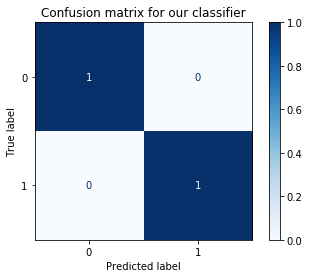

```python
matrix = plot_confusion_matrix(log_reg, X_test, y_test,
                                 cmap=plt.cm.Blues,
                                 normalize='true')
plt.title('Confusion matrix for our classifier')
plt.show(matrix)
plt.show()
```

## 9. Other Models

#### Decision Tree

```python
dc = DecisionTreeClassifier(max_leaf_nodes=3, random_state=42)

# Train the model on training data
dc.fit(X_train_SMOTE, y_train_SMOTE)

print(dc.score(X_train_SMOTE, y_train_SMOTE))
print(dc.score(X_test, y_test))
roc_auc_score(y_test, dc.predict(X_test))
```

```
1.0
1.0
```

```
1.0
```

#### Random Forest

```python
rf = RandomForestClassifier(n_estimators = 1000, random_state = 42)

# Train the model on training data
rf.fit(X_train_SMOTE, y_train_SMOTE)

print(round(rf.score(X_train_SMOTE, y_train_SMOTE),3))
print(round(rf.score(X_test, y_test),3))
round(roc_auc_score(y_test, rf.predict(X_test)),3)
```

```
1.0
0.966
```

```
0.667
```

#### Other Models that can be applied

SVM, XGBoost, NeuralNets

## 10. Conclusion

For random forest, the data is overfitting since the train data score is higher than the test data score. The ROC score is closer to 0.5 which means that its not a good model. Improvements can be made with GridSearchCV. But since logistic regression and decision tree are giving an roc score of 1, this means thats its able to distinguish very well between the events that are likely to be cancelled or not. More data would be needed to truly distinguish which model is better. True positive and true negative are balanced. The cancellation status can be predicted in terms of cases where the event is indoor and live events as shown by my graphs and charts.

#### If you had more time to work on this model, what data would you look to include next and why?

1. Look at relationships between events and weather within certain time frames. e.g. analyze weather data one-hour/ two-hours before the event. This can help with risk analysis.
2. Feature Engineering - Features that could be added: Time difference between event start time and close time, Days of the week
3. The reason for not using Month, Day, Minutes, Hours, Seconds in machine learning data is because it is cyclical. Perhaps use of sin and cos can help in achieving better results. With Unix time, leap seconds are ignored.

Other data that can be included to the dataset:

1. News can be included to detect early warnings or signs through repetitive mention of words/topics. NLP can be used for this.
2. Address of individuals attending the event - Helps us with understanding the distance travelled to the event. Helping to warn them earlier can save travel time and cost for individuals.

#### Improvements

1. Parallel processing with Dask - Can help with speeding up processing time
2. Chunking - Saves on memory